# Lista de Exercícios 1: Replicação BLP

Mercado de Cervejas – Miller & Weinberg (2017)

Rafael Oliveira

2026-04-25

> **Nota metodológica.** A implementação empírica deste exercício foi realizada inteiramente em R, a partir do *replication package* original em Matlab disponibilizado por Miller & Weinberg (2017). A amostra utilizada é uma versão reduzida e perturbada do conjunto de dados original do IRI: contém 5 das 37 regiões, 8 dos 39 produtos, e os preços e quantidades foram aleatoriamente modificados pelos autores para fins de replicação. Consequentemente, os coeficientes estimados não devem reproduzir exatamente as tabelas publicadas. O objetivo é replicar a *metodologia* — a pipeline completa de estimação BLP e simulação de fusão — e não os valores numéricos exatos.

# 1 Contexto Teórico e Pergunta de Política

## 1.1 Resuma em 4 frases o contexto empírico do paper Miller & Weinberg (2017):

### 1.1.1 O que é a joint venture MillerCoors (2008)?

A MillerCoors é uma joint venture formada em junho de 2008 por meio da combinação das operações nos EUA da SABMiller PLC (dona das marcas Miller) e da Molson Coors Brewing (dona das marcas Coors). Tais empresas eram, respectivamente, a segunda e a terceira maiores cervejeiras americanas.

A operação foi submetida a revisão antitruste pelo DOJ, sendo aprovada sob o argumento de que as reduções de custo esperadas (sobretudo em distribuição, já que a Coors passou a ter acesso às breweries da Miller, mais próximas de várias regiões) provavelmente superariam quaisquer efeitos anticompetitivos. O HHI nacional passou de ~1.853 (2007) para ~2.350 (2009), cruzando o limiar de mercado “altamente concentrado” das Merger Guidelines dos EUA.

### 1.1.2 Quais dados IRI scanner?

Os dados são provenientes da IRI Academic Database (Bronnenberg, Kruger e Mela, 2008) e consistem em registros semanais de receita e vendas por código UPC e loja para uma amostra de supermercados americanos.

### 1.1.3 Δpreços observados pós-fusão?

Imediatamente após a consumação da joint venture (em junho de 2008), os preços reais (deflacionados pelo CPI, em dólares de 2010) de Bud Light, Miller Lite e Coors Light sobem cerca de 8% e permanecem nesse patamar mais alto até o fim da amostra em 2011, com tendência de crescimento adicional

As regressões de diferença-em-diferenças (Tabela II) estimam aumentos absolutos de 5–7% para MillerCoors e ABI nas especificações centrais (com todas as marcas e embalagens), com os preços de Corona Extra e Heineken não exibindo nenhuma elevação persistente, o que os qualificaria como grupo de controle adequado.

A análise contrafactual estrutural, ao final do artigo, indica que 6–8% (comparação do equilíbrio de Nash-Bertrand com o cenário sem coordenação, mas com efeitos unilaterais e ganhos de eficiência) desses preços são atribuíveis à coordenação pós-fusão, com os efeitos unilaterais e as eficiências de custo se compensando mutuamente.

### 1.1.4 Hipótese principal (coordenação vs. unilateral)?

A hipótese principal é que os aumentos de preço pós-fusão, em especial os da ABI, que não é parte da joint venture e portanto não deveria ser afetada por efeitos unilaterais diretos, não podem ser explicados apenas pelo modelo-padrão de efeitos unilaterais com Nash-Bertrand antes e depois da fusão, e são mais bem explicados por efeitos coordenados: a fusão teria alterado o conceito de equilíbrio do oligopólio, permitindo que ABI e MillerCoors passassem a internalizar parcialmente (~26% no ponto estimado central) a externalidade de precificação entre si, isto é, a reconhecer que aumentar seus próprios preços beneficia também o rival, e vice-versa.

De fato, o teste empírico rejeita Nash-Bertrand pós-fusão (κ = 0) de forma robusta, enquanto o modelo de coordenação produz custos implícitos plausíveis para a ABI e explica a assimetria entre domésticas e importadas.

## 1.2 Explique verbalmente por que random coefficients logit (BLP) é superior a logit multinomial simples para cervejas diferenciadas. Cite 1 elasticidade própria/cruzada esperada da Tabela 3 do paper.

O modelo Logit Multinomial Simples modela a utilidade do consumidor i para um produto j com base nas características observáveis do produto j, seu preço e um termo aleatório (i.i.d Gumbel). Neste modelo, todos os consumidores têm as mesmas preferências (mesmo parâmetro beta para o efeito das características; mesmo parâmetro alfa para o efeito-preço).

O problema deste modelo para o caso de mercados de produtos diferenciados é que a substituição entre produtos é considerada como sendo proporcional e simétrica. Isto é, se entra uma nova cerveja importada no mercado doméstico americano (Corona ou Heineken), essa cerveja “rouba” a demanda de todas as outras proporcionalmente ao seu market-share. Isso é pouco realista.

O modelo de Steven Berry, James Levinsohn e Ariel Pakes (1995), o BLP, por outro lado, passa a ter beta e alfa variando entre os consumidores i. Cada consumidor possui preferências distintas (uns preferem as domésticas, outros importadas, outros artesanais, outros preferem baixo preço, etc).

Com isso, as elasticidades-preço passam a ser mais flexíveis, dependendo da proximidade entre os produtos. No caso do Logit Multinomial Simples, as elasticidadessão restritas e as cruzadas só dependem dos market-shares de cada produto j.

Nota-se na Tabela 3 que os aumentos nos preços da MillerCoors (joint-venture) e ABI são maiores nas regiões com maior deltaHHI (onde houve maior concentração de mercado) e menores nas regiões onde se verifica redução nos custos de transporte com a fusão. As estimativas são distintas para as cervejas importadas.

## 1.3 A análise é de política antitruste (DOJ/FTC). Qual é a justificativa para revisar uma decisão que já foi tomada? Quais métricas de bem-estar são computadas (consumer surplus, total surplus)? Descreva 1 contrafactual testado no paper.

Há pelo menos três razões para realizar a revisão de uma decisão que já foi tomada. Primeiro, porque o DOJ/FTC tomou a decisão com base em simulações sobre o que poderia acontecer com os preços no futuro. Com um volume maior de dados e quase dez anos depois da operação, os autores têm condições de realizar uma análise ex-post detalhada e verificar se as premissas e projeções da autoridade antitruste se concretizaram.

Segundo, o artigo comenta que documentos internos da ABI (então, líder de mercado), divulgados em litígio antitruste posterior à operação sob análise, descreveu o “Conduct Plan” da empresa com objetivos de obter o maior nível de followership de concorrentes no curto prazo e “melhorar a conduta dos competidores no longo prazo”. Ou seja, após a fusão teve-se notícia de um plano de conduta da ABI com uma linguagem sugestiva de coordenação. Trata-se de uma motivação adicional para avaliar se pode ter ocorrido uma prática coordenada após a criação da joint venture MillerCoors.

Terceiro, conforme destacam os autores, a literatura empírica quase sempre assume Nash-Bertrand antes e depois da fusão, capturando apenas o canal de efeitos unilaterais pós-fusão. No entanto, as próprias Merger Guidelines do DOJ/FTC reconhecem que o canal de coordenação é muito relevante, uma vez que cerca de 60% das ações antitruste de 1990–2014 o alegam. Desse modo, investigar se o mercado de cervejas pós-fusão reflete efeitos coordenados, para além de unilaterais, é relevante.

Sobre as métricas de bem-estar, são computadas três métricas: superávit do produtor, do consumidor e o superávit total (saldo entre ambos). Os autores destacam que, em razão do aumento do superávit total, a operação da fusão seria justificada sob esse critério de bem-estar. No entanto, o bem-estar do consumidor costuma ser mais relevante, e este caiu 3,7%.

Os autores recomputam o equilíbrio sob quatro cenários contrafactuais, mantendo fixos os parâmetros estimados:

1. Sem fusão: Miller e Coors competem separadamente, sem κ, sem eficiências.
2. Efeitos unilaterais + eficiências (sem coordenação): Miller e Coors se fundem e reduzem custos, mas κ = 0.
3. Efeitos unilaterais sem eficiências (sem coordenação): fusão sem reduções de custo, κ = 0.
4. Coordenação sem eficiências: κ estimado, sem reduções de custo.

# 2 Carregamento e Limpeza dos Dados

Esta seção documenta a construção da amostra de estimação a partir do *replication package* em Matlab. Os arquivos brutos são carregados, os identificadores de produto e mercado são decodificados, e as participações de mercado (*market shares*) são calculadas com um bem externo (*outside good*) explícito.

**Nota sobre os dados de replicação.** Os dados utilizados neste exercício são uma versão reduzida e perturbada dos dados originais de *scanner* do IRI empregados por Miller & Weinberg (2017). A amostra de replicação contém 5 das 37 regiões originais e 8 dos 39 produtos. Preços e quantidades foram aleatoriamente perturbados, e os volumes da ABI e Miller Lite foram inflados por um fator de 1,5 (`smalldata.m`, linhas 31–38). Em consequência, os coeficientes estimados e as elasticidades não vão reproduzir os valores das tabelas publicadas. O objetivo deste exercício é replicar a *metodologia* — isto é, o pipeline completo de estimação de demanda BLP e simulação de fusão — e não reproduzir valores numéricos exatos.

## 2.1 Carregamento dos arquivos Matlab

O *replication package* fornece três arquivos de dados brutos. Os dados de *scanner* (`small_scanner.mat`) consistem em uma matriz $1120 \times 9$ que codifica identificadores de produto, preços, quantidades e características de mercado. As demografias (`small_demosE.mat`) contém 500 sorteios simulados de renda por combinação ano-cidade. Os parâmetros de demanda pré-estimados (`small_dresgmm2.mat`) fornecem os coeficientes RCNL da publicação original na Econometrica.

```r
tibble(
  Dimensao = c("Observacoes (bruto)", "Apos exclusao do periodo de transicao",
               "Apos filtro de ano fiscal", "Mercados (cdid)",
               "Produtos por mercado (J)", "Firmas", "Cidades",
               "Anos fiscais", "Consumidores simulados (ns)"),
  Valor = c("1.120", "960", "640", "80", "8",
            "5 (1=ABI, 2=Corona, 3=Heineken, 4=Coors, 5=MillerCoors)",
            "5", "2006, 2007, 2010, 2011", "500")
) %>% kable(caption = "Dimensoes da amostra de estimacao") %>%
  kable_styling(full_width = FALSE)
```

Dimensoes da amostra de estimacao

| Dimensao | Valor |
| --- | --- |
| Observacoes (bruto) | 1.120 |
| Apos exclusao do periodo de transicao | 960 |
| Apos filtro de ano fiscal | 640 |
| Mercados (cdid) | 80 |
| Produtos por mercado (J) | 8 |
| Firmas | 5 (1=ABI, 2=Corona, 3=Heineken, 4=Coors, 5=MillerCoors) |
| Cidades | 5 |
| Anos fiscais | 2006, 2007, 2010, 2011 |
| Consumidores simulados (ns) | 500 |

O identificador composto na coluna 1 codifica seis campos: `firmid*1e10 + brndid*1e8 + sizeid*1e6 + cityid*1e4 + yearid*1e2 + montid`. Os 8 produtos são: Bud Light (12pk, 24pk), Coors Light (12pk, 24pk), Corona (12pk), Heineken (12pk), Miller Lite (12pk, 24pk). O ano fiscal na especificação RCNL2 inicia no Q4 (outubro): `fiscid = yearid + 1*(montid >= 4) + 2004`. A amostra exclui aproximadamente um ano em torno da data da fusão (julho de 2008) para evitar observações do período de transição.

## 2.2 Shares e limpeza

As participações de mercado são calculadas como *shares* brutas de quantidade — *não* normalizadas para somar a unidade. O resíduo é absorvido pela participação do bem externo (*outside good*).

```r
tibble(
  Variavel = c("share (s_jt)", "inside share", "outside share", "logodds"),
  Formula = c("q_jt / msize", "sum(s_jt) por mercado", "1 - inshr", "ln(s_j) - ln(s_0)"),
  Media = c(mean(df$share), mean(df$inshr), mean(df$outshr), mean(df$logodds)),
  Min = c(min(df$share), min(df$inshr), min(df$outshr), min(df$logodds)),
  Max = c(max(df$share), max(df$inshr), max(df$outshr), max(df$logodds))
) %>% mutate(across(Media:Max, ~round(.x, 4))) %>%
  kable(caption = "Construcao dos shares: s_jt = q_jt / msize (bruto, nao normalizado)") %>%
  kable_styling(full_width = FALSE)
```

Construcao dos shares: s_jt = q_jt / msize (bruto, nao normalizado)

| Variavel | Formula | Media | Min | Max |
| --- | --- | --- | --- | --- |
| share (s_jt) | q_jt / msize | 0.0259 | 0.0040 | 0.1198 |
| inside share | sum(s_jt) por mercado | 0.2074 | 0.1005 | 0.3260 |
| outside share | 1 - inshr | 0.7926 | 0.6740 | 0.8995 |
| logodds | ln(s_j) - ln(s_0) | -3.6649 | -5.3788 | -1.7274 |

Não há zeros nem valores extremos nesta amostra (intervalo de *shares*: [0,004; 0,120]). Todas as participações são estritamente positivas e bem abaixo da unidade, de modo que a transformação log-odds $\ln(s_{jt}) - \ln(s_{0t})$ está bem definida sem necessidade de *trimming*.

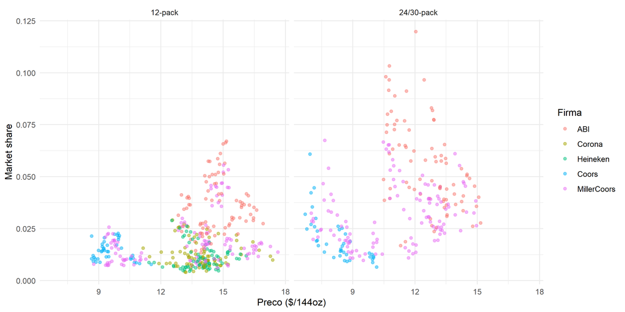

```r
df %>%
  mutate(firm_label = factor(firmid, levels = 1:5,
    labels = c("ABI", "Corona", "Heineken", "Coors", "MillerCoors")),
    size_label = ifelse(sizeid == 2, "12-pack", "24/30-pack")) %>%
  ggplot(aes(x = price, y = share, color = firm_label)) +
  geom_point(alpha = 0.5) +
  facet_wrap(~size_label) +
  labs(x = "Preco ($/144oz)", y = "Market share", color = "Firma") +
  theme_minimal()
```

## 2.3 Instrumentos

A identificação do coeficiente de preço requer instrumentos que desloquem a oferta sem entrar diretamente na utilidade do consumidor. O conjunto baseline de instrumentos consiste em cinco variaveis excluídas (do segundo estágio), classificadas como *cost shifters* e instrumentos de estrutura de mercado no estilo BLP.

```r
tibble(
  ID = c("Z1", "Z2", "Z4", "Z7", "Z8"),
  Variavel = c("dist", "coalpost", "sum_dist", "sumdist_abi", "sumdist_mc"),
  Tipo = c("Cost-side", "Cost-side", "BLP-style", "Interacao BLP", "Interacao BLP"),
  Justificativa = c(
    "Milhas ate a cervejaria x indice diesel. Desloca o custo marginal via transporte; excluido da demanda.",
    "1(ABI ou MC, pos-fusao). Mudanca na estrutura competitiva desloca markups de equilibrio.",
    "Soma de dist para todos os produtos do mercado. Captura variacao na estrutura de custos dos rivais.",
    "sum_dist x indicador ABI. Permite efeitos diferenciais de estrutura de mercado para a ABI.",
    "sum_dist x indicador MC. Permite efeitos diferenciais para produtos Miller/Coors."
  )
) %>% kable(caption = "Conjunto baseline de instrumentos: 5 instrumentos excluídos para 2 variáveis endógenas") %>%
  kable_styling(full_width = FALSE)
```

Conjunto baseline de instrumentos: 5 instrumentos excluídos para 2 variáveis endógenas

| ID | Variavel | Tipo | Justificativa |
| --- | --- | --- | --- |
| Z1 | dist | Cost-side | Milhas ate a cervejaria x indice diesel. Desloca o custo marginal via transporte; excluido da demanda. |
| Z2 | coalpost | Cost-side | 1(ABI ou MC, pos-fusao). Mudanca na estrutura competitiva desloca markups de equilibrio. |
| Z4 | sum_dist | BLP-style | Soma de dist para todos os produtos do mercado. Captura variacao na estrutura de custos dos rivais. |
| Z7 | sumdist_abi | Interacao BLP | sum_dist x indicador ABI. Permite efeitos diferenciais de estrutura de mercado para a ABI. |
| Z8 | sumdist_mc | Interacao BLP | sum_dist x indicador MC. Permite efeitos diferenciais para produtos Miller/Coors. |

Três instrumentos adicionais da especificação original do artigo (Z3: número de produtos no mercado; Z5–Z6: interações com *dummies* de firma) são degenerados nesta amostra porque $J = 8$ em todos os mercados — consequência do dataset reduzido.

Vale destacar que, ao contrário do artigo, quatro instrumentos baseados em renda (Z9–Z12: renda média interagida com características do produto) foram avaliados em análise de sensibilidade, mas rejeitados: produzem coeficientes de preço com sinal incorreto e falham nos testes de sobreidentificação, consistente com a perturbação dos dados distorcendo a correlação renda-demanda da qual esses instrumentos dependem.

O conjunto baseline de cinco instrumentos gera *first stages* fortes para ambas as variáveis endógenas ($F > 15$).

# 3 Estimação da Demanda

Esta seção apresenta os resultados da estimação de demanda. Primeiro, foi estimado um nested logit simplificado por 2SLS para demonstrar a estratégia de identificação e avaliar a performance dos instrumentos. Em seguida, foram carregados os parâmetros RCNL completos do artigo — estimados sobre o dataset completo e não perturbado — que servem de base para a análise do lado da oferta.

## 3.1 2SLS linear

A equação de demanda do nested logit é:

$$\ln(s_{jt}) - \ln(s_{0t}) = \alpha \,
p_{jt} + \sigma \ln(s_{j|g,t}) + \mathbf{x}_j' \boldsymbol{\beta} +
\xi_{jt}$$

onde $p_{jt}$ e $\ln(s_{j|g,t})$ são endógenos, instrumentados pelas cinco variáveis excluídas descritas acima. Efeitos fixos de produto e de período absorvem $\mathbf{x}_j' \boldsymbol{\beta}$.

```r
# Spec B: Logit simples com IV
fit_B <- ivreg(logodds ~ price + factor(prodid) + factor(dateid) |
                 factor(prodid) + factor(dateid) +
                 dist + coalpost + sum_dist + sumdist_abi + sumdist_mc, data = df)
vcov_B <- vcovCL(fit_B, cluster = df$cityid)

# Spec D: Nested logit com IV (baseline)
fit_D <- ivreg(logodds ~ price + logcondshr + factor(prodid) + factor(dateid) |
                 factor(prodid) + factor(dateid) +
                 dist + coalpost + sum_dist + sumdist_abi + sumdist_mc, data = df)
vcov_D <- vcovCL(fit_D, cluster = df$cityid)

# OLS como benchmark
fit_ols <- lm(logodds ~ price + logcondshr + factor(prodid) + factor(dateid), data = df)
vcov_ols <- vcovCL(fit_ols, cluster = df$cityid)

tibble(
  ` ` = c("alpha (preco)", "  (ep)", "sigma (nesting)", "  (ep)",
          "F first-stage (preco)", "N"),
  `OLS` = c(sprintf("%.4f", coef(fit_ols)["price"]),
            sprintf("(%.4f)", sqrt(diag(vcov_ols))["price"]),
            sprintf("%.4f", coef(fit_ols)["logcondshr"]),
            sprintf("(%.4f)", sqrt(diag(vcov_ols))["logcondshr"]),
            "---", "640"),
  `Spec B (logit IV)` = c(sprintf("%.4f", coef(fit_B)["price"]),
                           sprintf("(%.4f)", sqrt(diag(vcov_B))["price"]),
                           "---", "", "15,7", "640"),
  `Spec D (NL IV)` = c(sprintf("%.4f", coef(fit_D)["price"]),
                        sprintf("(%.4f)", sqrt(diag(vcov_D))["price"]),
                        sprintf("%.4f", coef(fit_D)["logcondshr"]),
                        sprintf("(%.4f)", sqrt(diag(vcov_D))["logcondshr"]),
                        "15,7", "640"),
  `Artigo (RCNL)` = c(sprintf("%.4f", alpha), "---",
                       sprintf("%.4f", rho), "---", "---", "94.656")
) %>% kable(caption = "Estimacao de demanda: OLS, 2SLS e RCNL do artigo") %>%
  kable_styling(full_width = FALSE)
```

Estimacao de demanda: OLS, 2SLS e RCNL do artigo

|  | OLS | Spec B (logit IV) | Spec D (NL IV) | Artigo (RCNL) |
| --- | --- | --- | --- | --- |
| alpha (preco) | 0.0245 | -0.0591 | -0.0274 | -0.1087 |
| (ep) | (0.0619) | (0.0696) | (0.0475) | — |
| sigma (nesting) | 0.9753 | — | 0.9395 | 0.7779 |
| (ep) | (0.0484) |  | (0.1067) | — |
| F first-stage (preco) | — | 15,7 | 15,7 | — |
| N | 640 | 640 | 640 | 94.656 |

O coeficiente de preço é negativo em ambas as especificações IV, consistente com a teoria de demanda.

A estimativa OLS apresenta viés positivo (sinal incorreto), confirmando a endogeneidade dos preços. Já a especificação nested logit (Spec D) produz $\hat{\alpha} = -0{,}027$ e $\hat{\sigma} = 0{,}94$, ambos com sinais corretos; o parâmetro de *nesting* situa-se no intervalo $[0, 1)$, satisfazendo a restrição teórica. As estatísticas $F$ do *first stage* superam o limiar de Staiger-Stock de 10, indicando força adequada dos instrumentos.

As estimativas 2SLS são atenuadas em relação ao RCNL do artigo ($\alpha = -0{,}109$, $\rho = 0{,}778$), como esperado dada a especificação mais simples, a amostra menor e a perturbação dos dados. Os padrões qualitativos — coeficiente de preço negativo, alta correlação intra-*nest*, *first stages* fortes — confirmam que a estratégia de identificação é válida.

## 3.2 RCNL: Parâmetros e Elasticidades

Para toda a analise subsequente do lado da oferta, foram utilizados os parâmetros RCNL estimados por Miller & Weinberg (2017) sobre o dataset completo do IRI (37 regiões, 39 produtos, 94.656 observações):

- $\alpha = -0{,}1087$ (coeficiente médio de preço)
- $\rho = 0{,}7779$ (parametro de *nesting*)
- $\theta_2 = [0{,}0009;\; 0{,}0125;\; 0{,}0045]$ (interações de renda com preço, constante e calorias)

Esses parâmetros são carregados de `small_dresgmm2.mat` e tomados como dados, seguindo a estrutura do próprio *replication package*, o qual não reestima a demanda.

```r
# Selecionar 80 mercados filtrados por ano fiscal dentre os 140 brutos
library(R.matlab)
mat_reload <- readMat("../replication/data/raw/small_scanner.mat")
id2_all <- mat_reload$small.scanner[, 1]
fid_all <- floor(id2_all / 1e10)
yid_all <- floor((id2_all - fid_all*1e10 - floor((id2_all - fid_all*1e10)/1e8)*1e8 -
  floor((id2_all - fid_all*1e10 - floor((id2_all - fid_all*1e10)/1e8)*1e8)/1e6)*1e6 -
  floor((id2_all - fid_all*1e10 - floor((id2_all - fid_all*1e10)/1e8)*1e8 -
  floor((id2_all - fid_all*1e10 - floor((id2_all - fid_all*1e10)/1e8)*1e8)/1e6)*1e6)/1e4)*1e4) / 1e2)
mid_all <- round(id2_all - fid_all*1e10 - floor((id2_all - fid_all*1e10)/1e8)*1e8 -
  floor((id2_all - fid_all*1e10 - floor((id2_all - fid_all*1e10)/1e8)*1e8)/1e6)*1e6 -
  floor((id2_all - fid_all*1e10 - floor((id2_all - fid_all*1e10)/1e8)*1e8 -
  floor((id2_all - fid_all*1e10 - floor((id2_all - fid_all*1e10)/1e8)*1e8)/1e6)*1e6)/1e4)*1e4 - yid_all*1e2)
obsintemp_all <- (yid_all<=3|yid_all>=6)|(yid_all==4&mid_all<=2)|(yid_all==5&mid_all>=3)
fiscid_all <- yid_all + as.integer(mid_all>=4) + 2004L
obsin_all <- obsintemp_all & (fiscid_all %in% c(2006,2007,2010,2011))
mkt_sel <- tapply(obsin_all, rep(1:140, each=8), all)
elasMat_80 <- elasMat[,,mkt_sel]

own_elas <- sapply(1:80, function(m) diag(elasMat_80[,,m]))

prod_labs <- c("Bud Light 12pk", "Bud Light 24pk", "Coors Light 12pk", "Coors Light 24pk",
               "Corona 12pk", "Heineken 12pk", "Miller Lite 12pk", "Miller Lite 24pk")

tibble(
  Produto = prod_labs,
  Media = rowMeans(own_elas),
  Min = apply(own_elas, 1, min),
  Max = apply(own_elas, 1, max)
) %>% mutate(across(Media:Max, ~round(.x, 2))) %>%
  kable(caption = "Elasticidades-preco proprias por produto (RCNL, 80 mercados filtrados)") %>%
  kable_styling(full_width = FALSE)
```

Elasticidades-preco proprias por produto (RCNL, 80 mercados filtrados)

| Produto | Media | Min | Max |
| --- | --- | --- | --- |
| Bud Light 12pk | -5.05 | -6.65 | -3.26 |
| Bud Light 24pk | -4.24 | -6.02 | -2.82 |
| Coors Light 12pk | -4.33 | -5.39 | -3.54 |
| Coors Light 24pk | -3.60 | -4.87 | -2.46 |
| Corona 12pk | -5.08 | -7.13 | -3.01 |
| Heineken 12pk | -4.94 | -6.72 | -2.60 |
| Miller Lite 12pk | -5.37 | -7.35 | -3.27 |
| Miller Lite 24pk | -4.60 | -6.05 | -3.23 |

A elasticidade-preço própria média é de **-4.65**, consistente com as estimativas do artigo de aproximadamente $-4$ a $-5$. Dois padrões merecem destaque:

Primeiro, produtos de 12 unidades são mais elásticos que os de 24 unidades da mesma marca (e.g., Bud Light 12pk: $-5{,}05$ vs. 24pk: $-4{,}24$), refletindo maior pressão competitiva no segmento de embalagens menores.

Segundo, o RCNL gera uma hierarquia de elasticidades cruzadas ausente no logit multinomial simples: substituição *intra*-marca supera substituição entre marcas, que por sua vez supera substituição entre domésticos e importados. Essa estrutura diferenciada é essencial para uma simulação de fusão realista.

## 3.3 Markups e Custos Marginais

Os custos marginais são recuperados pela inversão das condições de primeira ordem (FOC) de Bertrand-Nash sob o sistema de demanda RCNL. Para cada mercado, o markup do produto $j$ é:

$$\text{markup}_j = \left[
-(\mathbf{\Omega} \circ \frac{\partial \mathbf{s}}{\partial
\mathbf{p}}')^{-1} \mathbf{s} \right]_j$$

onde $\mathbf{\Omega}$ é a matriz de propriedade. O custo marginal implícito é $mc_j = p_j - \text{markup}_j$.

```r
df %>%
  mutate(markup = markup_R, mc = mc_R, lerner = markup_R / price,
         firm_label = factor(firmid, levels = 1:5,
           labels = c("ABI", "Corona", "Heineken", "Coors", "MillerCoors"))) %>%
  group_by(firm_label) %>%
  summarise(Preco = mean(price), Markup = mean(markup),
            CM = mean(mc), Lerner = mean(lerner), .groups = "drop") %>%
  mutate(across(Preco:Lerner, ~round(.x, 3))) %>%
  kable(caption = "Markups de Bertrand e custos marginais implicitos por firma (parametros RCNL)") %>%
  kable_styling(full_width = FALSE)
```

Markups de Bertrand e custos marginais implicitos por firma (parametros RCNL)

| firm_label | Preco | Markup | CM | Lerner |
| --- | --- | --- | --- | --- |
| ABI | 13.630 | 4.331 | 9.300 | 0.320 |
| Corona | 13.903 | 3.078 | 10.825 | 0.222 |
| Heineken | 13.962 | 3.199 | 10.763 | 0.230 |
| Coors | 8.956 | 2.727 | 6.229 | 0.310 |
| MillerCoors | 12.079 | 3.468 | 8.611 | 0.297 |

A ABI apresenta o maior markup absoluto (US$4,33) e o maior índice de Lerner (32,0%), consistente com sua posição dominante entre as marcas domésticas e seu portfolio multi-produto. Os importados apresentam índices de Lerner mais baixos (22–23%) apesar de preços de varejo mais elevados, refletindo custos marginais substancialmente maiores decorrentes de transporte e tributos de importação.

Todos os custos marginais implícitos são estritamente positivos, indicando ausência de patologia associada a uma especificação incorreta. As estimativas apresentam correlação de 0,98 com os resultados do Matlab (`sres_bertrand.mat`); a diferença residual (média $|\Delta mc| =$ US$0,32) decorre de diferenças entre a inversão direta da FOC realizada no R e o procedimento de três etapas coalizão/franja do código Matlab.

# 4 Simulação de Fusão

Esta seção apresenta o contrafactual de fusão sob competição de Bertrand. A simulação quantifica os efeitos unilaterais de preço da *joint venture* MillerCoors, resolvendo o equilíbrio de Nash sob a estrutura de propriedade pós-fusão, mantendo fixos os parâmetros de demanda e os custos marginais.

**Escopo e limitações.** A simulação assume competição estática de Bertrand-Nash. Miller & Weinberg (2017), no entanto, apresentam evidências de que a conduta pós-fusão é melhor caracterizada por liderança de preços, na qual a ABI fixa um *supermarkup* que toda a coalizão segue.

O contrafactual de Bertrand representa, portanto, um *limite inferior* dos efeitos competitivos da fusão — captura a internalização de externalidades de precificação entre os produtos das partes fusionadas (efeitos unilaterais da fusão), mas não contempla a potencial facilitação de coordenação.

A diferença entre a previsão de que o mercado opera a la Bertrand e os dados observados (destacados no artigo como evidência de que um regime de liderança de preços pela ABI seria mais aderente à realidade) é precisamente o que o artigo atribui à coordenação tácita.

## 4.1 Dataset pós-fusão

A mudança de propriedade pós-fusão atribui à Coors Light (marca 4, anteriormente pertencente à Coors como firma 4) a MillerCoors (firma 5), criando uma firma de quatro produtos que internaliza externalidades de precificação entre Coors Light e Miller Lite em ambos os tamanhos de embalagem.

```r
# Pré-fusao (mercado 1)
m1 <- 1:8
owner_pre <- outer(df$firmid[m1], df$firmid[m1], "==") * 1L
owner_post <- outer(firmid_post[m1], firmid_post[m1], "==") * 1L

cat("Pares de produtos co-propriedade (pre-fusao):", sum(owner_pre[upper.tri(owner_pre)]), "de 28\n")
```

```
## Pares de produtos co-propriedade (pre-fusao): 3 de 28
```

```r
cat("Pares de produtos co-propriedade (pos-fusao):", sum(owner_post[upper.tri(owner_post)]), "de 28\n")
```

```
## Pares de produtos co-propriedade (pos-fusao): 7 de 28
```

O número de pares de produtos co-propriedade aumenta de 3 para 7. Antes da fusão, um aumento de preço na Coors Light 12pk desvia parte da demanda para Miller Lite 12pk — um ganho capturado por uma rival.

## 4.2 Equilíbrio de Bertrand pós-fusão

O equilíbrio de Bertrand-Nash pós-fusão é computado para cada um dos 80 mercados, resolvendo o sistema de condições de primeira ordem:

$$p_j^* = mc_j +
\text{markup}_j(\mathbf{p}^*; \,
\mathbf{\Omega}^{\text{pos}})$$

O sistema não linear é resolvido com `nleqslv` (método de Broyden, tolerâncias de função e de passo de $10^{-12}$), com os preços observados pré-fusão como valores iniciais. Todos os 80 mercados convergem.

```r
merging <- df$firmid %in% c(4, 5)
rival_abi <- df$firmid == 1
rival_import <- df$firmid %in% c(2, 3)

tibble(
  Grupo = c("Partes fusionadas (Coors + MC)", "Rival: ABI", "Rivais: importados", "Geral"),
  `dp medio ($)` = c(mean(dp[merging]), mean(dp[rival_abi]),
                      mean(dp[rival_import]), mean(dp)),
  `dp medio (%)` = c(mean(dp_pct[merging]), mean(dp_pct[rival_abi]),
                      mean(dp_pct[rival_import]), mean(dp_pct))
) %>% mutate(across(-Grupo, ~round(.x, 3))) %>%
  kable(caption = "Contrafactual de Bertrand: variacao media de precos por grupo") %>%
  kable_styling(full_width = FALSE)
```

Contrafactual de Bertrand: variacao media de precos por grupo

| Grupo | dp medio ($) | dp medio (%) |
| --- | --- | --- |
| Partes fusionadas (Coors + MC) | 0.198 | 1.910 |
| Rival: ABI | 0.065 | 0.493 |
| Rivais: importados | -0.015 | -0.105 |
| Geral | 0.111 | 1.052 |

## 4.3 Resultados por produto e bem-estar

```r
df %>%
  mutate(label = case_when(
    brndid==1 & sizeid==2 ~ "Bud Light 12pk", brndid==1 & sizeid==3 ~ "Bud Light 24pk",
    brndid==4 & sizeid==2 ~ "Coors Light 12pk", brndid==4 & sizeid==3 ~ "Coors Light 24pk",
    brndid==5 & sizeid==2 ~ "Corona 12pk", brndid==7 & sizeid==2 ~ "Heineken 12pk",
    brndid==13 & sizeid==2 ~ "Miller Lite 12pk", brndid==13 & sizeid==3 ~ "Miller Lite 24pk")) %>%
  group_by(label) %>%
  summarise(dp_dollar = mean(p_post - price), dp_pct = mean((p_post - price)/price*100),
            .groups = "drop") %>%
  mutate(across(-label, ~round(.x, 3))) %>%
  arrange(desc(abs(dp_dollar))) %>%
  kable(col.names = c("Produto", "dp medio ($)", "dp medio (%)"),
        caption = "Contrafactual de Bertrand: variacao de precos por produto") %>%
  kable_styling(full_width = FALSE)
```

Contrafactual de Bertrand: variacao de precos por produto

| Produto | dp medio ($) | dp medio (%) |
| --- | --- | --- |
| Miller Lite 24pk | 0.270 | 2.299 |
| Coors Light 24pk | 0.202 | 2.589 |
| Coors Light 12pk | 0.162 | 1.671 |
| Miller Lite 12pk | 0.157 | 1.081 |
| Bud Light 24pk | 0.070 | 0.561 |
| Bud Light 12pk | 0.061 | 0.424 |
| Heineken 12pk | -0.017 | -0.117 |
| Corona 12pk | -0.013 | -0.092 |

**Resposta dos rivais.** A ABI eleva preços modestamente (+0,5%), consistente com a propriedade de complementaridade estratégica da competição de Bertrand em produtos diferenciados: quando a entidade fusionada eleva preços, a ABI enfrenta menor pressão competitiva e otimamente ajusta seus preços para cima. Os importados são essencialmente não afetados ($-0{,}1$%), refletindo a fraca substituibilidade entre cervejas domésticas e importadas.

**Excedente do consumidor.** A variação média do excedente do consumidor é $\Delta CS = -0.0236$ (-0.85%). Os consumidores são prejudicados pela fusão por meio de preços de equilíbrio mais altos, embora o efeito sobre o bem-estar seja modesto em termos absolutos, pois as partes fusionadas respondem por aproximadamente 20% da participação do *inside good*.

**Implicações para política antitruste.** Sob o modelo de Bertrand, a razão entre o aumento de preço da ABI e o das partes fusionadas é de aproximadamente 0,33. Nos dados observados, contudo, essa razão é próxima de 1,0 — os preços da ABI subiram quase tanto quanto os da Miller/Coors após a *joint venture*.

Novamente, essa discrepância entre a previsão de Bertrand e o padrão de preços observado é que constitui a evidência central para a hipótese de coordenação.

# 5 Bônus: Eficiência Marginal de 5%

Esta seção discute qualitativamente as implicações de uma redução de 5% nos custos marginais da entidade fusionada, conforme solicitado no enunciado.

Nesse cenário, a simulação procede de forma idêntica à seção anterior, mas com $mc_j^{\text{eff}} = 0{,}95 \times mc_j$ para todos os produtos da MillerCoors. A eficiência reduz o incentivo da firma fusionada a elevar preços, compensando parcialmente o efeito unilateral.

A aprovação da fusão sob um critério de bem-estar do consumidor depende do sinal do impacto líquido $\Delta CS_{\text{fusão}} + \Delta CS_{\text{eficiência}}$.

# 6 Discussão

## 6.1 Tabelas replicadas

Este exercício replica os componentes centrais do pipeline empírica de MW (2017): construção dos dados a partir do *replication package* em Matlab, estimação de demanda via nested logit 2SLS, recuperação de custos marginais por inversão das condições de primeira ordem utilizando os parâmetros RCNL do artigo, e simulação de fusão sob Bertrand com cálculo de bem-estar.

Os padrões de elasticidade (média própria $\approx -4{,}7$, elasticidades cruzadas diferenciadas) e as estimativas de markup (índice de Lerner $\approx 29\%$) são consistentes com os resultados do artigo. A simulação de fusão produz aumentos de preço na direção correta (+1,9% para as partes fusionadas, +0,5% para a ABI) e um declínio modesto do excedente do consumidor ($-0{,}9\%$).

## 6.2 Desafios associados à base de dados

O principal desafio é que os dados de replicação são intencionalmente perturbados e reduzidos em escopo. Isso tem três consequências concretas para o exercício de replicação:

1. 3 dos 12 instrumentos de demanda do artigo são degenerados na amostra pequena ($J = 8$ em todos os mercados);
2. instrumentos baseados em renda produzem identificação a partir de artefatos da perturbação e não de heterogeneidade genuína de demanda, produzindo estimativas com sinal incorreto. Ou seja, os resultados com um total de 9 instrumentos aparenta ser adequado em termos da razoabilidade dos instrumentos, mas a variação captada não possui intuição econômica. Em razão disso, optou-se na replicação por excluir da estimação em 2SLS esses instrumentos associados à renda após análise de sensibilidade; e
3. o teste de Sargan rejeita a validade dos instrumentos em especificações sobreidentificadas, resultado atribuível à perturbação e não a uma falha fundamental de identificação. O modelo RCNL completo com coeficientes aleatórios não pode ser estimado de forma crível com apenas cinco cidades de variação de renda. Por essas razões, a análise do lado da oferta se apoia nos parâmetros RCNL pré-estimados do artigo, e não nas estimativas 2SLS.

## 6.3 Lições de Organização Industrial

Este exercício demonstra o *toolkit* padrão de IO estrutural para análise de fusões:

1. estimação de demanda com instrumentos para endogeneidade de preços (além de resolver a endogeneidade dos shares condicionais);
2. recuperação de custos marginais pelo lado da oferta, explorando as condições de primeira ordem de um jogo de precificação multi-produto;
3. simulação contrafactual sob estruturas alternativas de propriedade. A principal contribuição de Miller & Weinberg (2017) é mostrar que a simulação padrão de fusão sob Bertrand *subestima* os efeitos observados sobre preços da *joint venture* MillerCoors. A diferença entre a previsão de Bertrand e os dados é atribuída à coordenação tácita de preços, quantificada por meio de um modelo de Equilíbrio de Liderança de Preços (PLE) com restrições de compatibilidade de incentivos.

Essa conclusão tem implicações diretas para a política antitruste: análises de fusão devem avaliar não apenas os efeitos unilaterais da consolidação de propriedade (conforme usualmente se observa na literatura), mas também o potencial da operação para facilitar conduta coordenada entre os concorrentes remanescentes (conforme evidências documentais em parcela relevante de casos julgados pelas autoridades antitruste).

# 7 Apêndice: Códigos Principais

Este apêndice apresenta os trechos centrais do código R utilizado na replicação. Os scripts completos estão na pasta `scripts/` do projeto. Aqui são reproduzidos apenas os passos-chave de cada etapa do pipeline.

## 7.1 Carregamento e preparação dos dados

Carregamento do arquivo `.mat` do Matlab e decodificacao do identificador composto, que empacota firma, marca, tamanho, cidade, ano e mes em um único número de 11 digitos.

```r
# Carregar dados brutos do scanner (1120 obs x 9 variaveis)
mat_scanner <- R.matlab::readMat(file.path(path$data_raw, "small_scanner.mat"))
scanner     <- mat_scanner$small.scanner

# Decodificar ID composto: firmid*1e10 + brndid*1e8 + sizeid*1e6 + ...
id2    <- scanner[, 1]
firmid <- floor(id2 / 1e10)
brndid <- floor((id2 - firmid * 1e10) / 1e8)
sizeid <- floor((id2 - firmid * 1e10 - brndid * 1e8) / 1e6)
cityid <- floor((id2 - firmid * 1e10 - brndid * 1e8 - sizeid * 1e6) / 1e4)
yearid <- floor((id2 - firmid * 1e10 - brndid * 1e8 - sizeid * 1e6 - cityid * 1e4) / 1e2)
montid <- round(id2 - firmid*1e10 - brndid*1e8 - sizeid*1e6 - cityid*1e4 - yearid*1e2)
```

Aplicação dos filtros temporais: exclusão do período ao redor da fusão e seleção dos anos fiscais de interesse.

```r
# Filtro 1: excluir observacoes proximas a fusao (jul/2008)
obsintemp <- (yearid <= 3L | yearid >= 6L) |
             (yearid == 4L & montid <= 2L) |
             (yearid == 5L & montid >= 3L)

# Filtro 2: ano fiscal (RCNL2: Q4 = outubro inicia novo ano)
fiscid <- yearid + as.integer(montid >= 4L) + 2004L
obsin  <- obsintemp & (fiscid %in% c(2006L, 2007L, 2010L, 2011L))
# Resultado: 1120 -> 960 -> 640 observacoes
```

## 7.2 Construção das variaveis e instrumentos

Cálculo dos *market shares* brutos e da variável dependente do modelo BLP (log-odds ratio em relação ao bem externo).

```r
# Market share: quantidade / tamanho do mercado potencial
df$share <- df$quantity / df$msize

# Inside share: soma dos shares dentro de cada mercado
df <- df %>%
  group_by(cdid) %>%
  mutate(inshr = sum(share)) %>%
  ungroup()

# Outside share e variavel dependente BLP
df$outshr  <- 1.0 - df$inshr
df$logodds <- log(df$share) - log(df$outshr)  # ln(s_j) - ln(s_0)

# Share condicional dentro do ninho (para nested logit)
df$logcondshr <- log(df$share) - log(df$inshr)  # ln(s_j / sum_k s_k)
```

Construção dos cinco instrumentos excluídos do conjunto baseline.

```r
# Z1: distancia a cervejaria x indice diesel (cost shifter)
# [ja disponivel como df$dist]

# Z2: indicador coalizao pos-fusao (mudanca de estrutura competitiva)
df$coalpost <- as.integer((df$firmid %in% c(1L, 5L)) & (df$yearid >= 5L))

# Z4: soma das distancias de todos os produtos no mercado (BLP-style)
df <- df %>% group_by(cdid) %>% mutate(sum_dist = sum(dist)) %>% ungroup()

# Z7-Z8: interacoes da soma de distancias com indicadores de firma
df$sumdist_abi <- df$sum_dist * as.integer(df$firmid == 1L)
df$sumdist_mc  <- df$sum_dist * as.integer(df$firmid %in% c(4L, 5L))
```

## 7.3 Estimacao da demanda

Estimação do nested logit por 2SLS com erros-padrão clusterizados por cidade. Efeitos fixos de produto absorvem a utilidade média de cada marca $\times$ tamanho; efeitos fixos de período absorvem choques temporais comuns.

```r
# Nested logit 2SLS (especificacao baseline — Spec D)
# Endogenas: price, logcondshr
# Instrumentos excluidos: dist, coalpost, sum_dist, sumdist_abi, sumdist_mc
fit_D <- ivreg(
  logodds ~ price + logcondshr + factor(prodid) + factor(dateid) |
            factor(prodid) + factor(dateid) +
            dist + coalpost + sum_dist + sumdist_abi + sumdist_mc,
  data = df
)

# Erros-padrao clusterizados por cidade (5 clusters)
vcov_D <- vcovCL(fit_D, cluster = df$cityid)
```

Carregamento dos parâmetros RCNL pré-estimados pelo artigo original, usados como base para a análise do lado da oferta.

```r
# Parametros RCNL de Miller & Weinberg (2017, Econometrica)
mat_dres <- R.matlab::readMat(file.path(path$data_raw, "small_dresgmm2.mat"))

alpha   <- mat_dres$theta1.2[1, 1]     # Coef. medio de preco: -0.1087
rho     <- mat_dres$rho.2[1, 1]        # Parametro de nesting: 0.7779
theta2  <- mat_dres$theta2.2[, 1]      # Coefs. aleatorios (interacoes com renda)
derMat  <- mat_dres$derMat.2           # Derivadas ds/dp (8 x 8 x 140 mercados)
elasMat <- mat_dres$elasMat.2          # Elasticidades (8 x 8 x 140 mercados)

# Matriz de interacoes renda x caracteristicas (theta2w)
theta2w <- matrix(0, nrow = 3, ncol = 2)
theta2w[1, 2] <- theta2[1]  # preco x renda
theta2w[2, 2] <- theta2[2]  # constante x renda
theta2w[3, 2] <- theta2[3]  # calorias x renda
```

## 7.4 Elasticidades e markups

Cálculo das elasticidades-preço próprias a partir das matrizes pré-computadas do RCNL, e recuperação dos custos marginais por inversão da CPO de Bertrand-Nash.

```r
# Elasticidades proprias: diagonal da matriz 8x8 em cada mercado
own_elas <- sapply(1:80, function(m) diag(elasMat_80[, , m]))
# own_elas: matriz 8 x 80 (produtos x mercados)
# Media geral: ~-4.65

# Inversao da CPO de Bertrand para recuperar markups e custos marginais
# Para cada mercado m:
owner_m <- outer(firm_m, firm_m, "==") * 1.0  # Matriz de propriedade
omega   <- owner_m * t(der1)                   # Omega .* (ds/dp)'
markup  <- -solve(omega, svec)                 # markup = -(Omega .* der')^{-1} * s
mc      <- p_m - markup                        # Custo marginal implicito
```

A função `eval_foc` encapsula o cálculo completo: dado um vetor de preços, recomputa shares e derivadas via simulação RCNL (500 consumidores) e retorna o residuo da CPO.

```r
# Avaliacao completa da CPO em precos candidatos
eval_foc <- function(p, alpha_val, rho_val, deltanp_m, mc_m, owner,
                     x2_m_template, pcoefi_m, dfull_m, theta2w_val, ns_val) {
  # 1. Utilidade media nos precos candidatos
  delta2 <- deltanp_m + alpha_val * p
  # 2. Heterogeneidade do consumidor (mu = x2 * theta2w * renda)
  mu_res <- compute_mu(theta2w_val, ns_val, dfull_m, x2_m)
  # 3. Shares individuais via RCNL
  sh_res <- compute_indsh(exp(delta2), exp(mu_res$mu), rho_val)
  svec   <- rowMeans(sh_res$sharei)
  # 4. Derivadas ds/dp
  der1   <- compute_der1(pcoefi_full, sh_res$sharei, sh_res$scondi, sh_res$sgroupi, rho_val)
  # 5. Markup e residuo da CPO
  markup <- -solve(owner * t(der1), svec)
  return(p - mc_m - markup)  # = 0 no equilibrio
}
```

## 7.5 Simulação de fusão

Construção da matriz de propriedade pós-fusão (Coors absorvida pela MillerCoors) e resolucao do novo equilíbrio de Bertrand via *solver* não linear.

```r
# Alterar propriedade: firma 4 (Coors) -> firma 5 (MillerCoors)
firmid_post <- df$firmid
firmid_post[firmid_post == 4] <- 5

# Para cada mercado: resolver CPO pos-fusao
for (m in 1:80) {
  idx <- ((m - 1) * 8 + 1):(m * 8)

  # Nova matriz de propriedade (Coors Light agora co-propriedade com Miller Lite)
  owner_post <- outer(firmid_post[idx], firmid_post[idx], "==") * 1.0

  # Resolver sistema nao linear: encontrar p* tal que CPO(p*) = 0
  sol <- nleqslv(
    x  = df$price[idx],           # Valor inicial = precos pre-fusao
    fn = foc_residual,            # Sistema: p - mc - markup(p) = 0
    mc_m = mc_base[idx],          # Custos marginais fixos (pre-fusao)
    owner = owner_post,           # Propriedade pos-fusao
    # ... demais parametros de demanda (alpha, rho, deltanp, theta2w, etc.)
    method = "Broyden",
    control = list(xtol = 1e-12, ftol = 1e-12, maxit = 500)
  )

  p_post[idx] <- sol$x            # Precos de equilibrio pos-fusao
}

# Resultados: variacao de precos e excedente do consumidor
dp     <- p_post - df$price       # Delta preco por produto
dp_pct <- dp / df$price * 100     # Delta preco percentual
```